# Feb-2019 Ford GoBike Trip Dataset Exploration

## by Walid Ismail

## Introduction

Our dataset includes information about individual rides made in a bike-sharing system covering the greater San Francisco Bay area. In the following sections, we will analyze the information in the dataset and see what insights we can discover from it about rides and cyclists demographics.

### What is the structure of your dataset?

The dataset consists of approx 180k observations and 23 columns (included derived columns)

### What is/are the main feature(s) of interest in your dataset?

Each observation includes information about trip start/end time as well as start/end station. In addition we get information about the bike used and the gender/birth year of the cyclist taking the trip.

### What features in the dataset do you think will help support your investigation into your feature(s) of interest?

The following feature are good subjects for analysis:

- Trip start time
- Trip day
- Trip city
- Trip duration (in minutes)
- Cyclist age/age group
- Cyclist gender
- Stations latitude / longitude

## Univariate Exploration

In this section we use histograms / bar charts to discover distributions of numeric / categorical features.

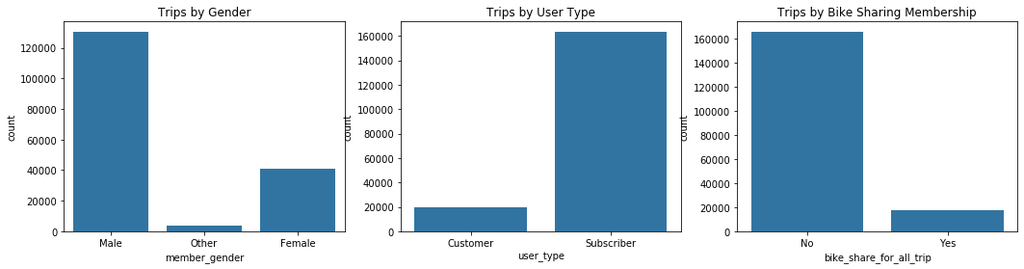

```python
plt.figure(figsize=(24, 4))
ax = plt.subplot(1, 4, 1)
sb.countplot(data=df_trips, x='member_gender', color=sb.color_palette()[0])
plt.title("Trips by Gender")

plt.subplot(1, 4, 2)
sb.countplot(data=df_trips, x='user_type', color=sb.color_palette()[0])
plt.title("Trips by User Type")

plt.subplot(1, 4, 3)
sb.countplot(data=df_trips, x='bike_share_for_all_trip', color=sb.color_palette()[0])
plt.title("Trips by Bike Sharing Membership");
```

The above charts show that our cyclists are mostly males, and mostly subscribers. Also note that most trips are for cyclists not enrolled in the **Bike Share for All** program for low-income residents

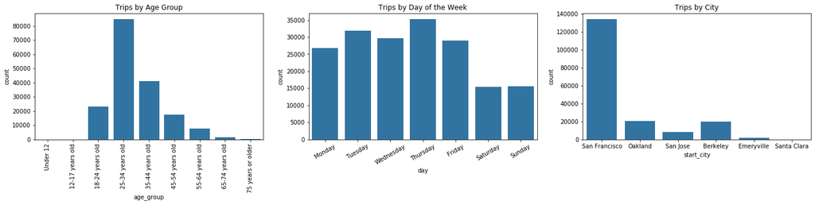

```python
plt.figure(figsize=(24, 4))

# What is the number of trips by age group?
plt.subplot(1, 3, 1)
sb.countplot(data=df_trips, x='age_group', color=sb.color_palette()[0])
plt.xticks(rotation=90);
plt.title("Trips by Age Group");

plt.subplot(1, 3, 2)
sb.countplot(data=df_trips, x='day', color=sb.color_palette()[0])
plt.xticks(rotation=30);
plt.title("Trips by Day of the Week");

plt.subplot(1, 3, 3)
sb.countplot(data=df_trips, x='start_city', color=sb.color_palette()[0])
plt.title("Trips by City");
```

The above charts show that most of our cyclists are in **San Francisco** and in the **25-34 age group**. We can also see that most trips are taken on **Thursdays** and notice a sharp decline in the number of trip during the weekend. Maybe our cyclists are using their rides to commute to work??

```
Mean trip duration = 12.10130725724962 minutes
Number of trips above 50 minutes = 2322
Number of trips above 100 minutes = 909
```

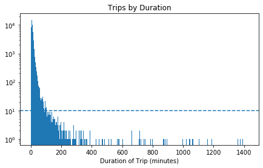

```python
plt.figure(figsize=(24, 4))

plt.subplot(1, 3, 1)
bins = np.arange(0, df_trips.duration_min.max()+1, 1)
plt.hist(data = df_trips, x = 'duration_min', bins = bins);
plt.xlabel("Duration of Trip (minutes)")
plt.yscale("log")
plt.title("Trips by Duration");
plt.axhline(10, linestyle = '--')
print("Mean trip duration = {} minutes".format(df_trips['duration_min'].mean()))
print("Number of trips above 50 minutes = {}".format((df_trips['duration_min'] > 50).sum()))
print("Number of trips above 100 minutes = {}".format((df_trips['duration_min'] > 100).sum()))
```

We can see from the above distribution that most of the trips are in the **5-10 minutes range** with a **trip mean of 12 minutes** and a long skew to the right of long individual trips.

```python
import folium # map rendering library

f = folium.Figure(width=1200, height=450)

address = 'Bay Area, California'

#geolocator = Nominatim(user_agent="to_explorer")
location = geolocator.geocode(address)
latitude = location.latitude
longitude = location.longitude
print('The geograpical coordinate of San Francisco Bay Area are {}, {}.'.format(latitude, longitude))

# create map of New York using latitude and longitude values
map_sanfrancisco = folium.Map(location=[latitude, longitude], zoom_start=11)

# add markers to map
for lat, lng, id, name, color, radius in zip(df_start_stations['start_station_latitude'], df_start_stations['start_station_longitude'], df_start_stations['start_station_id'], df_start_stations['start_station_name'], df_start_stations['color'], df_start_stations['trip_cat']):
    label = '{}, {}'.format(id, name)
    label = folium.Popup(label, parse_html=True)
    folium.CircleMarker(
        [lat, lng],
        radius=(radius+2)*2,
        popup=label,
        color=color,
        fill=True,
        fill_color=color,
        fill_opacity=0.7,
        parse_html=False).add_to(map_sanfrancisco)

f.add_child(map_sanfrancisco)
f
```

```
The geograpical coordinate of San Francisco Bay Area are 37.7884969, -122.3558473.
```

[interactive chart not shown]

By zooming on the map we can see that most trips start from the stations on **Market Street** and **Townsend Street** in San Francisco. For Berkeley most trips start on **Bancroft Way**.

```python
f = folium.Figure(width=1200, height=450)

# create map of New York using latitude and longitude values
map_sanfrancisco = folium.Map(location=[latitude, longitude], zoom_start=11)

# add markers to map
for lat, lng, id, name, color, radius in zip(df_end_stations['end_station_latitude'], df_end_stations['end_station_longitude'], df_end_stations['end_station_id'], df_end_stations['end_station_name'], df_end_stations['color'], df_end_stations['trip_cat']):
    label = '{}, {}'.format(id, name)
    label = folium.Popup(label, parse_html=True)
    folium.CircleMarker(
        [lat, lng],
        radius=(radius+2)*2,
        popup=label,
        color=color,
        fill=True,
        fill_color=color,
        fill_opacity=0.7,
        parse_html=False).add_to(map_sanfrancisco)

f.add_child(map_sanfrancisco)
f
```

[interactive chart not shown]

The above map shows that most trips end at stations on **Market Street** and **Townsend Street** too. For Berkeley most trips end on **Bancroft Way**.

#### We can summarize the findings from our univariate plots as follows:

- Our cyclists are mostly males, and mostly subscribers.
- The vast majority of trips are for cyclists not enrolled in the **Bike Share for All** program for low-income residents.
- The majority of trips are in San Francisco followed by Oakland and Berkeley
- Most of our cyclists are in the **25-34 age group**.
- Most trips are taken on **Thursdays**.
- We see a sharp decline in the number of trip during the weekend.
- The average trip duration is 12 minutes with vast majority of trips falling the 5-10 minutes range.

## Bivariate Exploration

In this section we explore relationships between different sets of two variables.

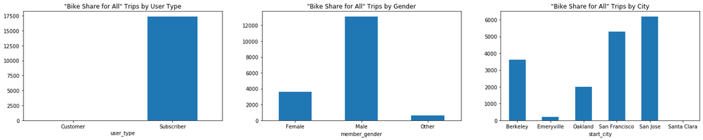

```python
plt.figure(figsize=(24, 4))
#plt.subplots(2, 3)

ax = plt.subplot(1, 3, 1)
# Number of trips by gender and user_type
df_trips.groupby(['user_type', 'bike_share_for_all_trip']).size().unstack()['Yes'].plot(kind='bar', ax=ax, title = '"Bike Share for All" Trips by User Type', rot=0)

ax = plt.subplot(1, 3, 2)
# Number of trips by gender and user_type
df_trips.groupby(['member_gender', 'bike_share_for_all_trip']).size().unstack()['Yes'].plot(kind='bar', ax=ax, title = '"Bike Share for All" Trips by Gender', rot=0)

ax = plt.subplot(1, 3, 3)
# In which city are most "Bike Share for All" rides taken??
df_trips.groupby(['start_city', 'bike_share_for_all_trip']).size().unstack()['Yes'].plot(kind='bar', ax=ax, title = '"Bike Share for All" Trips by City', rot=0);
```

We can see from charts above:

- All **"Bike Share for All"** trips are taken by **Subscribers**.
- Also, the vast majority of them are **males** and their trips are mainly in **San Jose, San Francisco and Berkeley**.

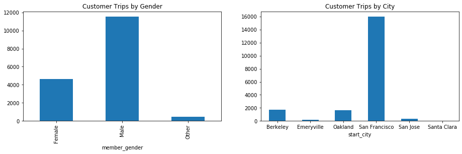

```python
plt.figure(figsize=(24, 4))

ax = plt.subplot(1, 3, 1)
# Number of trips by gender and user_type
df_trips.groupby(['member_gender', 'user_type']).size().unstack()['Customer'].plot(kind='bar', ax=ax, title = 'Customer Trips by Gender', rot=90)

ax = plt.subplot(1, 3, 2)
# In which city are most "Bike Share for All" rides taken??
df_trips.groupby(['start_city', 'user_type']).size().unstack()['Customer'].plot(kind='bar', ax=ax, title = 'Customer Trips by City', rot=0);
```

We can see from charts above:

- The vast majority of Customer trips are taken by males.
- The vast majority of Customer trip are in San Francisco.

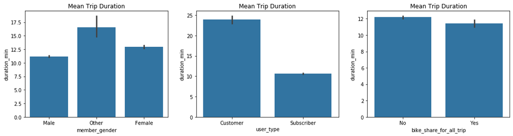

```python
plt.figure(figsize=(24, 4))

plt.subplot(1,4,1)
sb.barplot(data=df_trips, x='member_gender', y='duration_min', color=sb.color_palette()[0])
#plt.xticks(rotation=90);
plt.title("Mean Trip Duration");

plt.subplot(1,4,2)
sb.barplot(data=df_trips, x='user_type', y='duration_min', color=sb.color_palette()[0])
#plt.xticks(rotation=90);
plt.title("Mean Trip Duration");

plt.subplot(1,4,3)
sb.barplot(data=df_trips, x='bike_share_for_all_trip', y='duration_min', color=sb.color_palette()[0])
#plt.xticks(rotation=90);
plt.title("Mean Trip Duration");
```

We observe the following insights with regards to mean duration of trips:

- Average trip duration is highest for "Other" gender category.
- Trip duration is slightly higher for females than males.
- Average trips duration for Customers is more than double that for Subscribers.
- Cyclists in the "Bike Share for All" program take slightly shorter trips than other Cyclists.

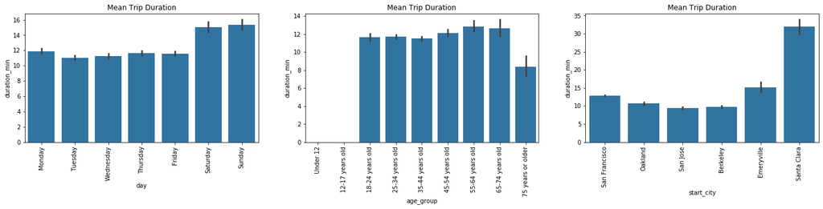

```python
plt.figure(figsize=(24, 4))

plt.subplot(1,3,1)
sb.barplot(data=df_trips, x='day', y='duration_min', color=sb.color_palette()[0])
plt.title("Mean Trip Duration");
plt.xticks(rotation=90);

plt.subplot(1,3,2)
sb.barplot(data=df_trips, x='age_group', y='duration_min', color=sb.color_palette()[0])
plt.xticks(rotation=90);
plt.title("Mean Trip Duration");

plt.subplot(1,3,3)
sb.barplot(data=df_trips, x='start_city', y='duration_min', color=sb.color_palette()[0])
plt.title("Mean Trip Duration");
plt.xticks(rotation=90);
```

Note the following:

- Mean trip duration is approx the same across weekdays (with a notable increase in the weekend).
- Trip duration is practically the same across age groups with those in above 75 years age group taking shorter trip on average.
- Average trip durations in Santa Clara is almost double trip durations in other cities.

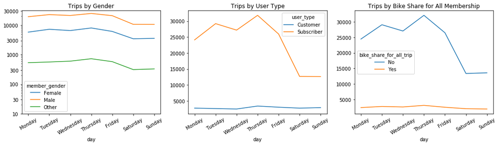

```python
plt.figure(figsize=(24, 4))

ax = plt.subplot(1, 4, 1)
df_trips.groupby(['day', 'member_gender']).size().unstack().plot(ax = ax)
plt.title("Trips by Gender");
plt.xticks(rotation = 30)
plt.yscale('log')
ticks = [10, 30, 100, 300, 1000, 3000, 10000, 30000]
# Convert ticks into string values, to be displayed along the x-axis
labels = ['{}'.format(v) for v in ticks]
plt.yticks(ticks, labels)

ax = plt.subplot(1, 4, 2)
df_trips.groupby(['day', 'user_type']).size().unstack().plot(ax = ax)
plt.title("Trips by User Type");
plt.xticks(rotation = 30);

ax = plt.subplot(1, 4, 3)
df_trips.groupby(['day', 'bike_share_for_all_trip']).size().unstack().plot(ax = ax)
plt.title("Trips by Bike Share for All Membership");
plt.xticks(rotation = 30);
```

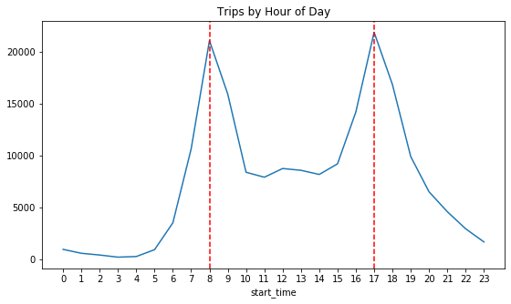

```python
fig = plt.figure(figsize = [20,5])

ax = plt.subplot(1, 2, 1)
df_trips.groupby([df_trips['start_time'].dt.hour]).size().plot()
plt.title("Trips by Hour of Day");

plt.axvline(8, linestyle = '--', color='r')
plt.xticks([_ for _ in range(24)])
plt.axvline(17,linestyle = '--', color='r');
```

The line plot above show a very interesting trend. We can clearly see that **most of the trips start at 8AM and at 5PM** which is a strong sign that cyclists use our bikes to commute to/from work. We also see a smaller flat peek of around a 10000 trips during the whole week between 10 AM and 3PM.

#### We can summarize our bivariate findings as follows:

- Average trip duration is highest for "Other" gender category.
- Trip duration is slightly higher for females tha males.
- Average trips duration for Customers is more than double that for Subscribers.
- Cyclists in the "Bike Share for All" program take slightly shorter trips than other Cyclists.
- Mean trip duration is approx the same across weekdays (with a notable increase in the weekend days).
- Trip duration is practically the same across age groups with those in above 75 years age group taking shorter trip on average.
- The vast majority of them are >males and their trips are mainly in San Jose, San Francisco and Berkeley.

#### The following relationships are interesting:

- The vast majority of Customer trip are in San Francisco.
- Average trip durations in Santa Clara is almost double trip durations in other cities.
- ALL **"Bike Share for All"** trips are taken by **Subscribers**.
- Most of the trips start at 8AM and at 5PM which is a strong sign that cyclists use our bikes to commute to/from work.

## Multivariate Exploration

In this section we explore relationships between different sets of three or more variables.

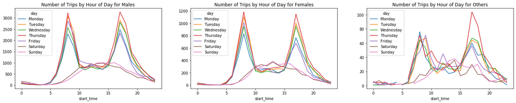

```python
fig, axes = plt.subplots(ncols = 3, figsize = [24,4])

df_trips[df_trips['member_gender'] == "Male"].pivot_table(index=df_trips['start_time'].dt.hour,
                     columns='day',
                     values='user_type',
                     aggfunc='count').plot(title = "Number of Trips by Hour of Day for Males", ax = axes[0]);

df_trips[df_trips['member_gender'] == "Female"].pivot_table(index=df_trips['start_time'].dt.hour,
                     columns='day',
                     values='user_type',
                     aggfunc='count').plot(title = "Number of Trips by Hour of Day for Females", ax = axes[1]);

df_trips[df_trips['member_gender'] == "Other"].pivot_table(index=df_trips['start_time'].dt.hour,
                     columns='day',
                     values='user_type',
                     aggfunc='count').plot(title = "Number of Trips by Hour of Day for Others", ax = axes[2]);
```

Note the aggregate hourly trend for trips continues across gender (male/female) but it different for Others with one big peak at 5 PM, a smaller peak at 8 AM and peaks in-between.

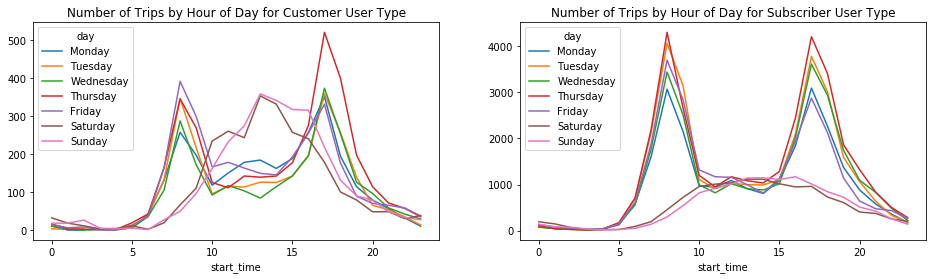

```python
fig, axes = plt.subplots(ncols = 2, figsize = [16,4])

df_trips[df_trips['user_type'] == "Customer"].pivot_table(index=df_trips['start_time'].dt.hour,
                     columns='day',
                     values='user_type',
                     aggfunc='count').plot(title = "Number of Trips by Hour of Day for Customer User Type", ax = axes[0]);

df_trips[df_trips['user_type'] == "Subscriber"].pivot_table(index=df_trips['start_time'].dt.hour,
                     columns='day',
                     values='user_type',
                     aggfunc='count').plot(title = "Number of Trips by Hour of Day for Subscriber User Type", ax = axes[1]);
```

Note the difference in the trend for Customers which is has peak during the weekend and is not flat unlike Subscribers

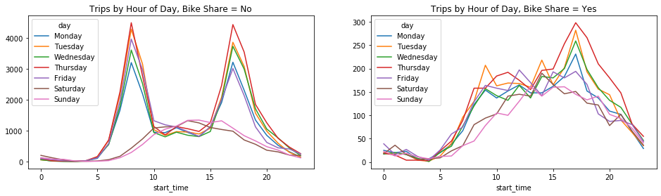

```python
fig, axes = plt.subplots(ncols = 2, figsize = [16,4])

df_trips[df_trips['bike_share_for_all_trip'] == "No"].pivot_table(index=df_trips['start_time'].dt.hour,
                     columns='day',
                     values='user_type',
                     aggfunc='count').plot(title = "Trips by Hour of Day, Bike Share = No", ax = axes[0]);

df_trips[df_trips['bike_share_for_all_trip'] == "Yes"].pivot_table(index=df_trips['start_time'].dt.hour,
                     columns='day',
                     values='user_type',
                     aggfunc='count').plot(title = "Trips by Hour of Day, Bike Share = Yes", ax = axes[1]);
```

The hourly trend for cyclists enrolled in the "Bike Share for All" program looks nothing like the one for other cyclists. It appears cyclists in the program use their bike more evenly through the day unlike the bi-modal pattern of other cyclists.

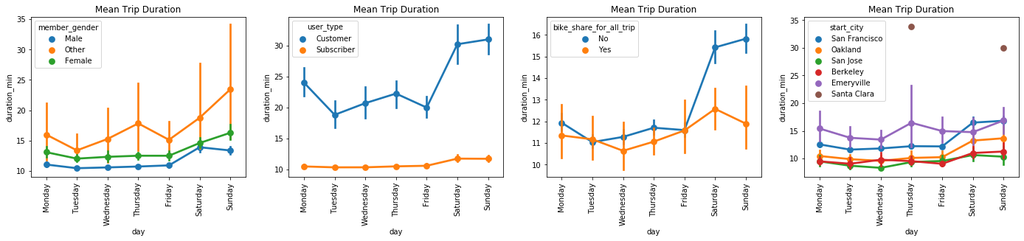

```python
plt.figure(figsize=(24, 4))

plt.subplot(1,4,1)
sb.pointplot(data=df_trips, x='day', y='duration_min', hue='member_gender')
plt.title("Mean Trip Duration");
plt.xticks(rotation=90);

plt.subplot(1,4,2)
sb.pointplot(data=df_trips, x='day', y='duration_min', hue='user_type')
plt.title("Mean Trip Duration");
plt.xticks(rotation=90);

plt.subplot(1,4,3)
sb.pointplot(data=df_trips, x='day', y='duration_min', hue='bike_share_for_all_trip')
plt.title("Mean Trip Duration");
plt.xticks(rotation=90);

plt.subplot(1,4,4)
sb.pointplot(data=df_trips, x='day', y='duration_min', hue='start_city')
plt.title("Mean Trip Duration");
plt.xticks(rotation=90);
```

#### We can summarize our multivariate findings as follows:

- The aggregate hourly trend for trips continues across gender (male/female).
- The aggregate hourly trend for trips continues for Subscribers.
- The aggregate hourly trend for trips continues for those not enrolled in the "Bike Share for All" program.
- The high average duration of trips continues for "Other" gender across the days of the week compared to males and females.
- "Customers" continue to take longer trips across the days of the week.
- The trip duration is practically the same for those enrolled in the "Bike Share" program across the week, while it increases considerably for those not enrolled in the program during the weekend compared to the weekdays.

#### The following relationships are interesting:

- There is a noticeable difference in the hourly trend for "Others" gender type.
- It is noticeably different for Customer user type too with relatively high number of trips in the weekend compared to the trend observed for Subscribers.
- It is also different for those enrolled in the "Bike Share for All" program with trips relatively high across the day.

## Conclusions

The analysis of the dataset provides the following insights:

- The vast majority of trips are taken by males.
- The vast majority of trips are for cyclists not enrolled in the **Bike Share for All** program.
- The majority of trips are in San Francisco.
- Most of our cyclists are in the 25-34 age group.
- Most trips are taken on Thursdays.
- We see a sharp decline in the number of trip during the weekend.
- The average trip duration is 12 minutes.
- ALL "Bike Share for All" trips are taken by Subscribers. Most of their trips are taken in San Jose followed by San Francisco and then Berkeley.
- Most of the trips start at 8AM and at 5PM which is a strong sign that cyclists use our bikes to commute to/from work.